# week6

## Question 9.1

Using the same crime data set uscrime.txt as in Question 8.2, apply Principal Component Analysis and then create a regression model using the first few principal components. Specify your new model in terms of the original variables (not the principal components), and compare its quality to that of your solution to Question 8.2. You can use the R function prcomp for PCA. (Note that to first scale the data, you can include scale. = TRUE to scale as part of the PCA function. Don’t forget that, to make a prediction for the new city, you’ll need to unscale the coefficients (i.e., do the scaling calculation in reverse)!)

Read data

```r
crime_data=read.table("http://www.statsci.org/data/general/uscrime.txt", header = TRUE)


summary(crime_data)
```

```
##        M               So               Ed             Po1
##  Min.   :11.90   Min.   :0.0000   Min.   : 8.70   Min.   : 4.50
##  1st Qu.:13.00   1st Qu.:0.0000   1st Qu.: 9.75   1st Qu.: 6.25
##  Median :13.60   Median :0.0000   Median :10.80   Median : 7.80
##  Mean   :13.86   Mean   :0.3404   Mean   :10.56   Mean   : 8.50
##  3rd Qu.:14.60   3rd Qu.:1.0000   3rd Qu.:11.45   3rd Qu.:10.45
##  Max.   :17.70   Max.   :1.0000   Max.   :12.20   Max.   :16.60
##       Po2               LF              M.F              Pop
##  Min.   : 4.100   Min.   :0.4800   Min.   : 93.40   Min.   :  3.00
##  1st Qu.: 5.850   1st Qu.:0.5305   1st Qu.: 96.45   1st Qu.: 10.00
##  Median : 7.300   Median :0.5600   Median : 97.70   Median : 25.00
##  Mean   : 8.023   Mean   :0.5612   Mean   : 98.30   Mean   : 36.62
##  3rd Qu.: 9.700   3rd Qu.:0.5930   3rd Qu.: 99.20   3rd Qu.: 41.50
##  Max.   :15.700   Max.   :0.6410   Max.   :107.10   Max.   :168.00
##        NW              U1                U2            Wealth
##  Min.   : 0.20   Min.   :0.07000   Min.   :2.000   Min.   :2880
##  1st Qu.: 2.40   1st Qu.:0.08050   1st Qu.:2.750   1st Qu.:4595
##  Median : 7.60   Median :0.09200   Median :3.400   Median :5370
##  Mean   :10.11   Mean   :0.09547   Mean   :3.398   Mean   :5254
##  3rd Qu.:13.25   3rd Qu.:0.10400   3rd Qu.:3.850   3rd Qu.:5915
##  Max.   :42.30   Max.   :0.14200   Max.   :5.800   Max.   :6890
##       Ineq            Prob              Time           Crime
##  Min.   :12.60   Min.   :0.00690   Min.   :12.20   Min.   : 342.0
##  1st Qu.:16.55   1st Qu.:0.03270   1st Qu.:21.60   1st Qu.: 658.5
##  Median :17.60   Median :0.04210   Median :25.80   Median : 831.0
##  Mean   :19.40   Mean   :0.04709   Mean   :26.60   Mean   : 905.1
##  3rd Qu.:22.75   3rd Qu.:0.05445   3rd Qu.:30.45   3rd Qu.:1057.5
##  Max.   :27.60   Max.   :0.11980   Max.   :44.00   Max.   :1993.0
```

```r
head(crime_data)
```

```
##      M So   Ed  Po1  Po2    LF   M.F Pop   NW    U1  U2 Wealth Ineq     Prob
## 1 15.1  1  9.1  5.8  5.6 0.510  95.0  33 30.1 0.108 4.1   3940 26.1 0.084602
## 2 14.3  0 11.3 10.3  9.5 0.583 101.2  13 10.2 0.096 3.6   5570 19.4 0.029599
## 3 14.2  1  8.9  4.5  4.4 0.533  96.9  18 21.9 0.094 3.3   3180 25.0 0.083401
## 4 13.6  0 12.1 14.9 14.1 0.577  99.4 157  8.0 0.102 3.9   6730 16.7 0.015801
## 5 14.1  0 12.1 10.9 10.1 0.591  98.5  18  3.0 0.091 2.0   5780 17.4 0.041399
## 6 12.1  0 11.0 11.8 11.5 0.547  96.4  25  4.4 0.084 2.9   6890 12.6 0.034201
##      Time Crime
## 1 26.2011   791
## 2 25.2999  1635
## 3 24.3006   578
## 4 29.9012  1969
## 5 21.2998  1234
## 6 20.9995   682
```

```r
#Split into training and test data, 80-20 split
set.seed(290)
ind<-sample(2,nrow(crime_data), replace=TRUE, prob=c(0.8,0.2))
training<- crime_data[ind==1,]
testing<- crime_data[ind==2,]
```

From week5, the regression model for the given data is as follows

```r
lm.final<-lm(Crime ~ M+Ed+Ineq+Prob+Po1+U2, data=training)
summary(lm.final)
```

```
##
## Call:
## lm(formula = Crime ~ M + Ed + Ineq + Prob + Po1 + U2, data = training)
##
## Residuals:
##     Min      1Q  Median      3Q     Max
## -530.57  -82.41    9.28  112.82  427.97
##
## Coefficients:
##             Estimate Std. Error t value Pr(>|t|)
## (Intercept) -3814.58     962.38  -3.964 0.000441 ***
## M              51.41      36.90   1.393 0.174158
## Ed            147.20      49.43   2.978 0.005811 **
## Ineq           68.55      14.88   4.606 7.57e-05 ***
## Prob        -2988.35    1509.04  -1.980 0.057228 .
## Po1           134.51      14.94   9.002 6.77e-10 ***
## U2             38.04      49.67   0.766 0.449939
## ---
## Signif. codes:  0 '***' 0.001 '**' 0.01 '*' 0.05 '.' 0.1 ' ' 1
##
## Residual standard error: 188 on 29 degrees of freedom
## Multiple R-squared:  0.8177, Adjusted R-squared:   0.78
## F-statistic: 21.68 on 6 and 29 DF,  p-value: 1.683e-09
```

The final linear regression model is: Crime_Pred = -3814.58 + 51.41 * M + 147.20 * Ed+ 68.55 * Ineq + -2988.35 * Prob + 134.51 * Po1 + 38.04 * U2

```r
#Lets construct the test dataframe for the test data and use it to predict the crime rate
testDf<-data.frame(M=14.0,Ed=10.0, Ineq=20.1,Prob=0.04,Po1=12.0,U2=3.6)

testDf
```

```
##    M Ed Ineq Prob Po1  U2
## 1 14 10 20.1 0.04  12 3.6
```

```r
crime_rate<-predict(lm.final,testDf)

#Crime Rate
crime_rate
```

```
##        1
## 1386.417
```

### PCA

Now lets use Principal Component Analysis to find the principal components

```r
pca<-prcomp(training[-16],scale. = TRUE, center = TRUE )

#Lets look at the summary
summary(pca)
```

```
## Importance of components:
##                           PC1    PC2    PC3     PC4     PC5     PC6     PC7
## Standard deviation     2.4597 1.5849 1.4635 1.15259 1.03870 0.64505 0.62109
## Proportion of Variance 0.4034 0.1675 0.1428 0.08856 0.07193 0.02774 0.02572
## Cumulative Proportion  0.4034 0.5708 0.7136 0.80218 0.87410 0.90184 0.92756
##                            PC8     PC9    PC10    PC11    PC12    PC13    PC14
## Standard deviation     0.55296 0.49098 0.43030 0.37465 0.32295 0.23621 0.22286
## Proportion of Variance 0.02038 0.01607 0.01234 0.00936 0.00695 0.00372 0.00331
## Cumulative Proportion  0.94794 0.96401 0.97636 0.98571 0.99267 0.99639 0.99970
##                           PC15
## Standard deviation     0.06724
## Proportion of Variance 0.00030
## Cumulative Proportion  1.00000
```

Looking at the proportion of variance, PC1 explains 40% of the variance in the data, followed by 16%, 14% by PC2 and PC3. The other principal components attribute to very less variance. However looking at the cumulative proportion of the variance, upto 80% of variance is accounted for by the first 4 principal components.

Lets look at some of the plots to further analyze.

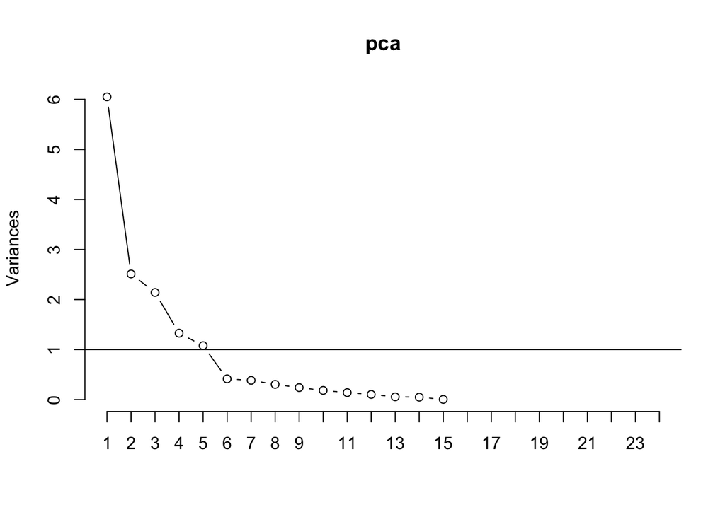

```r
library(stats)
screeplot(pca,npcs = 24, type = "lines")
abline(a=1,b=0)
```

Prediction with principal components

```r
prd <- predict(pca,training[-16])
prd <- data.frame(prd,training$Crime)
colnames(prd)[16]<-'Crime'

#A data frame of the original data expressed in principal components
head(prd)
```

```
##          PC1         PC2         PC3        PC4        PC5         PC6
## 1 -3.9189594  0.53327628  1.01975156 -0.5093951 -0.1315718 -0.38784538
## 3 -3.7496157 -0.66729672  0.02650128 -0.2480580 -0.4896131 -0.81231827
## 4  3.7830522  3.48132680  0.47588154 -0.3667682  1.4192435 -0.04355533
## 6  3.0882661  0.59618505 -0.07933286 -1.0658910 -1.6393074  0.47663156
## 7  0.4646288 -0.08173907  1.10723983 -0.9257291 -0.9259023  0.57743197
## 8  0.1290593  1.63245035 -0.07902775 -1.4715333 -0.1330020 -0.32720793
##           PC7         PC8          PC9       PC10       PC11        PC12
## 1 -0.09659665 -0.45553744  0.466721505 -0.2952905 -0.1540645  0.15207724
## 3  0.08875215  0.18418451 -0.039293635 -0.1623153  0.5053998 -0.24886541
## 4 -1.90669049 -0.04918452 -0.004485786 -0.3223367  0.1562592  0.07994703
## 6  0.63754129  0.26517706  0.384297102  0.2700918  0.2036412 -0.51808050
## 7  1.20894599  0.36365155 -0.688307835 -1.0143712 -0.3148369 -0.40104590
## 8  0.46453631  0.91390353 -0.154765745 -0.7239748  0.4055563  0.41488358
##         PC13        PC14         PC15 Crime
## 1  0.3592704 -0.01640230 -0.033798363   791
## 3 -0.3311202  0.13926089 -0.060778718   578
## 4  0.1857819  0.03432839 -0.035064966  1969
## 6  0.2435717  0.11228439  0.003587270   682
## 7  0.2365461 -0.33489463  0.040409442   963
## 8 -0.5079842  0.17941063 -0.009016021  1555
```

Lets train a linear regression model with the first 4 components

```r
model_pca<-lm(Crime~PC1+PC2+PC3+PC4 , data=prd)

summary(model_pca)
```

```
##
## Call:
## lm(formula = Crime ~ PC1 + PC2 + PC3 + PC4, data = prd)
##
## Residuals:
##     Min      1Q  Median      3Q     Max
## -639.35 -114.50   -0.95  167.75  629.71
##
## Coefficients:
##             Estimate Std. Error t value Pr(>|t|)
## (Intercept)   873.64      49.86  17.523  < 2e-16 ***
## PC1            70.38      20.56   3.424  0.00176 **
## PC2           115.86      31.90   3.632  0.00100 **
## PC3            10.14      34.55   0.294  0.77105
## PC4          -114.69      43.87  -2.614  0.01367 *
## ---
## Signif. codes:  0 '***' 0.001 '**' 0.01 '*' 0.05 '.' 0.1 ' ' 1
##
## Residual standard error: 299.1 on 31 degrees of freedom
## Multiple R-squared:  0.5066, Adjusted R-squared:  0.443
## F-statistic: 7.958 on 4 and 31 DF,  p-value: 0.0001554
```

Looking at the p-values for the co-efficients above, it looks like PC1, PC2 and PC4 are the co-efficients that are statistically significant (p-value <=0.05)

Lets train the final model with PC1, PC2 and PC4

```r
model_pca_final<-lm(Crime~PC1+PC2+PC4 , data=prd)
summary(model_pca_final)
```

```
##
## Call:
## lm(formula = Crime ~ PC1 + PC2 + PC4, data = prd)
##
## Residuals:
##     Min      1Q  Median      3Q     Max
## -642.00 -101.89   -2.98  163.72  641.35
##
## Coefficients:
##             Estimate Std. Error t value Pr(>|t|)
## (Intercept)   873.64      49.14  17.779  < 2e-16 ***
## PC1            70.38      20.26   3.474 0.001495 **
## PC2           115.86      31.44   3.685 0.000842 ***
## PC4          -114.69      43.24  -2.653 0.012327 *
## ---
## Signif. codes:  0 '***' 0.001 '**' 0.01 '*' 0.05 '.' 0.1 ' ' 1
##
## Residual standard error: 294.8 on 32 degrees of freedom
## Multiple R-squared:  0.5053, Adjusted R-squared:  0.4589
## F-statistic: 10.89 on 3 and 32 DF,  p-value: 4.349e-05
```

Predict for new data

- M = 14.0
- So = 0
- Ed = 10.0
- Po1 = 12.0
- Po2 = 15.5
- LF = 0.640
- M.F = 94.0
- Pop = 150
- NW = 1.1
- U1 = 0.120
- U2 = 3.6
- Wealth = 3200
- Ineq = 20.1
- Prob = 0.04
- Time = 39.0

```r
testDf<-data.frame(M = 14.0,
So = 0,
Ed = 10.0,
Po1 = 12.0,
Po2 = 15.5,
LF = 0.640,
M.F = 94.0,
Pop = 150,
NW = 1.1,
U1 = 0.120,
U2 = 3.6,
Wealth = 3200,
Ineq = 20.1,
Prob = 0.04,
Time = 39.0)

#Calculate the PCA components for the test data set
pca_test<-data.frame(predict(pca,testDf))

print(pca_test[,1:4][-3])
```

```
##       PC1      PC2      PC4
## 1 1.22263 3.427617 1.092654
```

```r
#Crime rate for the given test data
predict(model_pca_final,pca_test[,1:4][-3])
```

```
##        1
## 1231.486
```

We get a value of 1231.486 as the Crime rate for the given test data. We had gotten a value of 1386.417 for the same dataset for the non-pca regression model from week5. Now which one is better ?

### Accuracy of the Models, k-folds validation and RMSE check

```r
# Accuracy calculation
tst<-predict(pca,testing[-16])
tst<-data.frame(tst,testing$Crime)
head(tst)
```

```
##          PC1        PC2         PC3        PC4        PC5         PC6
## 2   1.435603 -0.3822552  0.04808423 -0.2052549  1.0871195  0.39659431
## 5   2.210373 -0.8357134 -1.30542560 -0.9006805 -0.1607276  0.47529659
## 9  -3.194526  0.6470387 -1.35868412 -0.7770527  0.1517145 -0.01107398
## 20  2.164593  1.7015384  3.19334739  0.5880086  0.6166748 -0.79422265
## 29  3.399469  5.4469669  0.35895819 -0.3365238 -0.5997188 -0.40537457
## 32  1.706201  1.5966318  0.71818574  1.0289519 -0.2840494 -1.04844527
##            PC7        PC8        PC9        PC10        PC11        PC12
## 2   0.38323297  0.2868449 0.52991818  0.18720292  0.01009749  0.55780878
## 5  -0.28583232  0.1001936 0.45846677 -0.20992278  0.31954639  0.48595281
## 9  -0.05561664 -0.2876301 0.25622494  0.03917758 -0.13376671 -0.33719511
## 20 -0.27129037 -0.1792500 0.60699972  0.02802514 -0.89341102 -0.16858100
## 29 -1.19614588 -0.3346713 0.22953608  0.37216640  1.03600456 -0.05743498
## 32 -0.71774215 -0.5686457 0.08214764 -0.17162960 -0.64203069 -0.61695179
##           PC13       PC14        PC15 testing.Crime
## 2   0.07016110 -0.2792188  0.09173715          1635
## 5   0.38471549  0.9014502  0.05306615          1234
## 9   0.13003975  0.2269787 -0.02672810           856
## 20 -0.06725783 -0.5021851  0.06697596          1225
## 29 -0.18679099  0.6243983 -0.04957011          1043
## 32  0.08334428 -0.4185961  0.11601704           754
```

```r
#Confusion matrix PCA model vs non-pca model
p<-predict(model_pca_final, tst[,1:4][-3])

actuals_preds <- data.frame(cbind(actuals=testing$Crime, predicteds=p))
cor(actuals_preds)
```

```
##              actuals predicteds
## actuals    1.0000000  0.2126925
## predicteds 0.2126925  1.0000000
```

```r
# Lot of miscalculations
head(actuals_preds)
```

```
##    actuals predicteds
## 2     1635   953.9269
## 5     1234  1035.6766
## 9      856   812.9035
## 20    1225  1155.6766
## 29    1043  1782.5647
## 32     754  1060.6885
```

```r
#Lets look at non-pca models accuracy
p<-predict(lm.final, testing)

actuals_preds <- data.frame(cbind(actuals=testing$Crime, predicteds=p))

cor(actuals_preds)
```

```
##              actuals predicteds
## actuals    1.0000000  0.6245515
## predicteds 0.6245515  1.0000000
```

```r
head(actuals_preds)
```

```
##    actuals predicteds
## 2     1635  1347.6232
## 5     1234  1302.5876
## 9      856   722.1274
## 20    1225  1192.2099
## 29    1043  1727.6873
## 32     754   796.3329
```

The accurracy of both the models are quite low, however the non-pca version seems to be performing well. Lets do k-fold validation to get a good representation of all the data.

K-fold validation

```r
#Lets try k-fold cross validation to ensure if all of the representations are capctured
library(caret)
library(dplyr)
set.seed(123)
train.control <- trainControl(method = "cv", number = 10)
# Train the model
model_non_pca <- train(Crime ~ M+Ed+Ineq+Prob+Po1+U2, data = crime_data, method = "lm",
               trControl = train.control)

# Get the PCA components for the entire dataset
prd <- predict(pca,crime_data[-16])
prd <- data.frame(prd,crime_data$Crime)
colnames(prd)[16]<-'Crime'

model_pca <- train(Crime ~ PC1+PC2+PC4, data = prd, method = "lm",
               trControl = train.control)
```

Compare the results

```
##        Model     RMSE  Rsquared      MAE
## 1 Non-PCA-lm 203.2122 0.7554810 166.8729
## 2        PCA 308.0319 0.4039616 249.2978
```

Lowest RMSE is the preferred model, based on the comparison above we deduce that the for the given dataset, the non-pca regression model from week5 performs better than the PCA model.

```r
#Final predictions for the test data
predict(model_non_pca,testDf)
```

```
##        1
## 1304.245
```